# Assignment - Week 09

Flurin Schindele

2026-05-11

```r
suppressPackageStartupMessages({
  library(GenomicRanges)
  library(epiwraps)
  library(ggplot2)
  library(rGREAT) # Gene Ontology enrichment among genomic regions
})
dir.create("data", showWarnings = FALSE)
options(timeout = 6000)
download.file(
  url = "https://ethz-ins.org/content/clustering_assignment.zip",
  destfile = "data/clustering.zip")
unzip("data/clustering.zip", exdir = "data")
```

```r
tracks <- list.files(path="data", pattern = ".bw$", full.names = TRUE)
peaks <- lapply(list.files(path="data", pattern = ".bed$", full.names = TRUE), rtracklayer::import.bed)
peaks <- lapply(peaks, FUN=function(x) x[x$score>800])
# concat the individual regions to one GRanges object:
regions_concat <- reduce(unlist(GRangesList(peaks)))
```

```r
ese <- signal2Matrix(tracks, regions_concat, extend=2000)
```

```
## Reading data/Creb1.bw
```

```
## Reading data/Creb3.bw
```

```
## Reading data/Creb3L1.bw
```

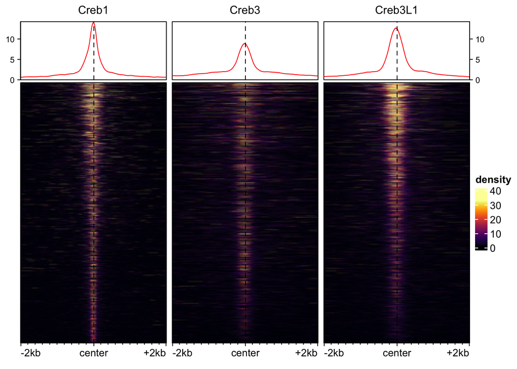

```r
plotEnrichedHeatmaps(ese, cluster_rows = FALSE)
```

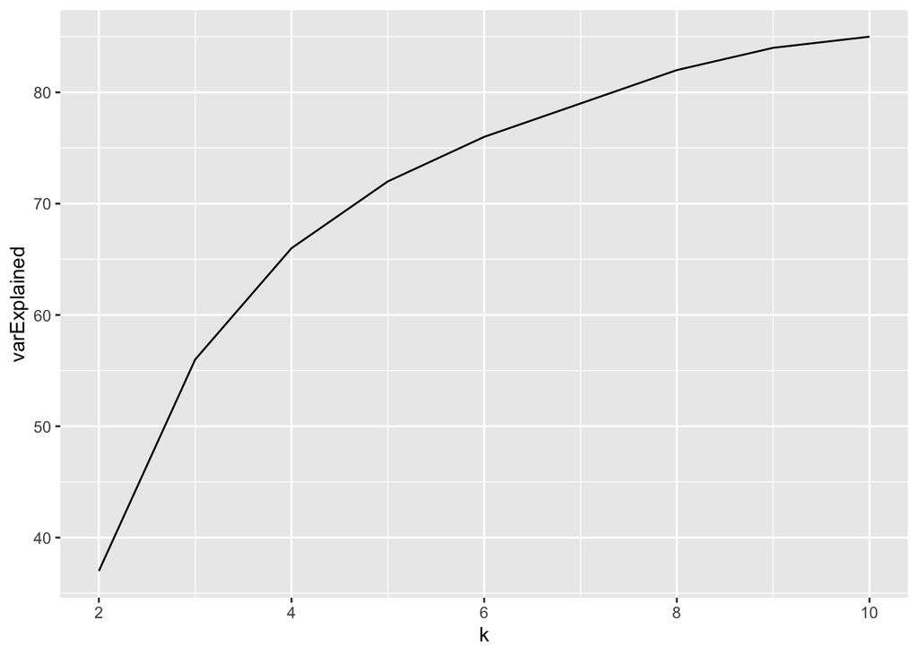

```r
set.seed(42)
cl2 <- clusterSignalMatrices(ese, k=2:10)
ggplot(cl2$varExplained, aes(k, varExplained)) + geom_line()
```

```r
rowData(ese)$cluster <- cl2$clusters[[4]]
head(rowData(ese))
```

```
## DataFrame with 6 rows and 1 column
##                     cluster
##                    <factor>
## chr1:778487-779069        3
## chr1:904436-904985        2
## chr1:941785-942096        4
## chr1:943126-943501        4
## chr1:959088-959463        4
## chr1:961148-961904        4
```

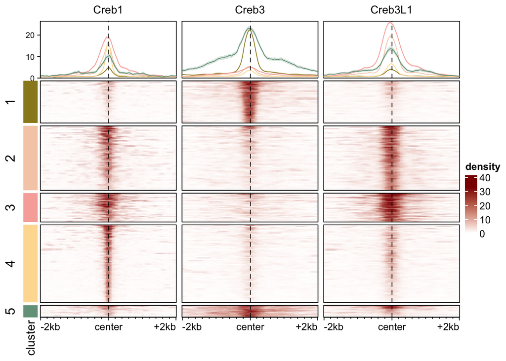

```r
# color palette for 5 clusters:
mycolors <-wesanderson::wes_palette("Royal2", 5)
names(mycolors) <- c("1", "2", "3", "4", "5")
plotEnrichedHeatmaps(ese, row_split="cluster", mean_color=mycolors, colors=c("white","darkred"))
```

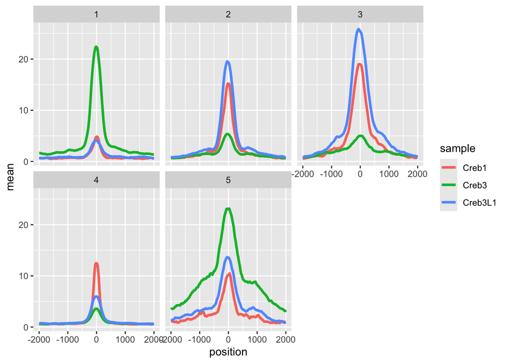

```r
d <- meltSignals(ese, splitBy=cl2$clusters[[4]])
ggplot(d, aes(position, mean, colour=sample)) + geom_line(linewidth = 1.2) + facet_wrap(~split)
```

Cluster 2 and 3 look very similar, with slightly different magnitudes of the signal. This should be taken into consideration when doing other analyses and we could try clustering based on the scaled row data. The signals from Creb1 and Creb3L1 are pretty highly correlated, whereas Creb3 has a different pattern.

```r
split_regions <- split(rowRanges(ese), rowData(ese)$cluster)
lengths(split_regions)
```

```
##   1   2   3   4   5
## 425 650 291 783 120
```

```r
res <- great(split_regions[["1"]], gene_sets="GO:BP", tss_source="hg38",
             background=regions_concat, cores=8)
```

```
## * TSS source: TxDb.
```

```
## * check whether TxDb package 'TxDb.Hsapiens.UCSC.hg38.knownGene' is installed.
```

```
## * gene ID type in the extended TSS is 'Entrez Gene ID'.
```

```
## * restrict chromosomes to 'chr1, chr2, chr3, chr4, chr5, chr6, chr7, chr8, chr9, chr10,
##     chr11, chr12, chr13, chr14, chr15, chr16, chr17, chr18, chr19, chr20, chr21, chr22, chrX,
##     chrY, chrM'.
```

```
## * 18193/35138 protein-coding genes left.
```

```
## * update seqinfo to the selected chromosomes.
```

```
## * TSS extension mode is 'basalPlusExt'.
```

```
## * construct the basal domains by extending 5000bp to upstream and 1000bp to downsteram of TSS.
```

```
## * calculate distances to neighbour regions.
```

```
## * extend to both sides until reaching the neighbour genes or to the maximal extension.
```

```
## * use GO:BP ontology with 15197 gene sets (source: org.Hs.eg.db).
```

```
## * check gene ID type in `gene_sets` and in `extended_tss`.
```

```
## * use self-defined background regions.
```

```
## * remove excluded regions from background.
```

```
## * overlap `gr` to background regions (based on midpoint).
```

```
## * in total 425 `gr`.
```

```
## * overlap extended TSS to background regions.
```

```
## * check which genes are in the gene sets.
```

```
## * only take gene sets with size >= 5.
```

```
## * in total 2491 gene sets.
```

```
## * overlap `gr` to every extended TSS.
```

```
## * perform binomial test for each biological term.
```

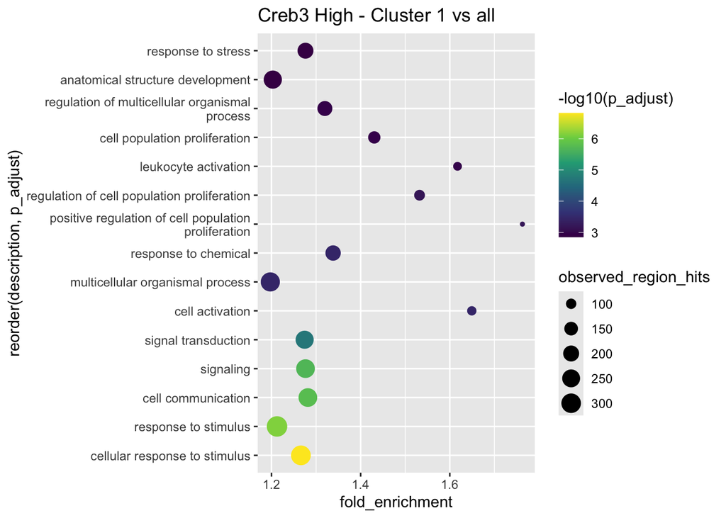

```r
bp <- getEnrichmentTables(res)
ggplot(head(bp,15), aes(fold_enrichment, reorder(description, p_adjust),
                        size=observed_region_hits, color=-log10(p_adjust))) +
  geom_point() + scale_color_viridis_c() +
  scale_y_discrete(labels = function(x) stringr::str_wrap(x, width = 45)) +
  ggtitle("Creb3 High - Cluster 1 vs all")
```

Cluster 1 with high Creb3 signal is enriched for terms related to responses to general stimuli as well as stress. Creb3 seems to be involved in communication and signaling as well. There is also an enriched proliferation/multicellular organisation pattern visible. This is somewhat in line with the [description](https://www.genecards.org/cgi-bin/carddisp.pl?gene=CREB3&keywords=creb3) of the protein, as it is ER bound and then cleaved in response to cellular stress which then allows it to translocate to the nucleus.

```r
res_2_3 <- great(split_regions[["2"]], gene_sets="GO:BP", tss_source="hg38",
             background=split_regions[["3"]], cores=4, verbose=FALSE)
bp_2_3 <- getEnrichmentTables(res_2_3)
nrow(bp_2_3)
```

```
## [1] 0
```

When we check for biological processes that might be enriched between cluster 2 and 3, we find no significant terms. This is not surprising, as the two clusters look very similar in terms of their signal patterns and their difference might arise from technical artifacts. This could also be due to the small size of the sets of regions we are comparing in this case. We can try to compare the two clusters to the entire background of all regions.

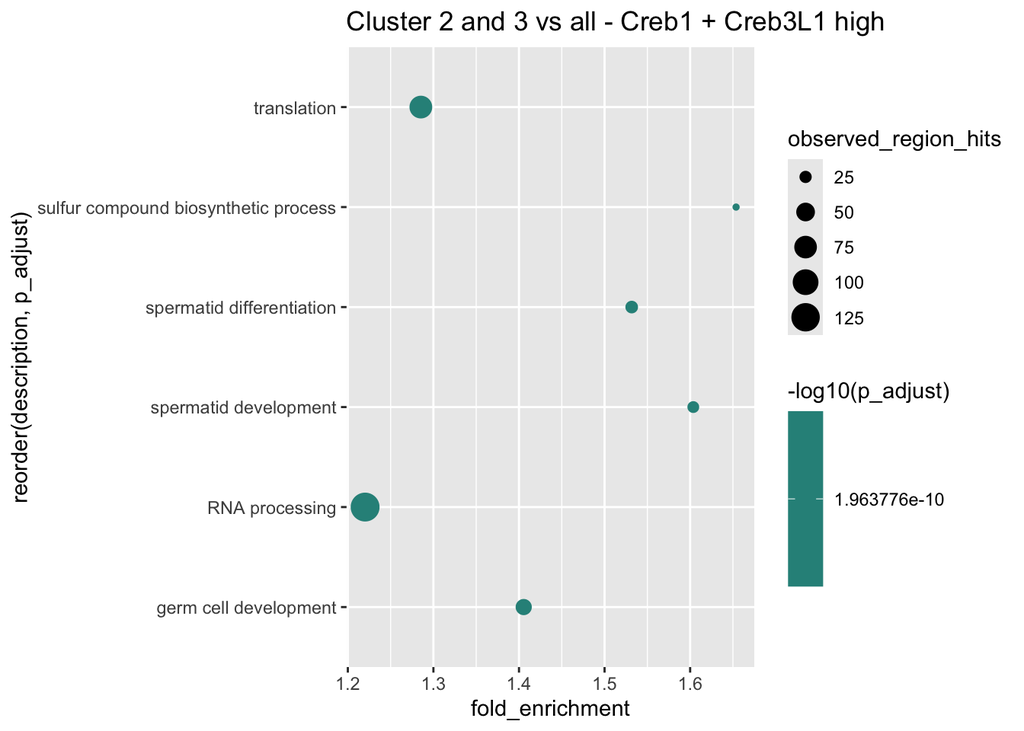

```r
res_23 <- great(c(split_regions[["2"]], split_regions[["3"]], ignore.mcols=FALSE), gene_sets="GO:BP", tss_source="hg38",
             background=regions_concat, cores=4, verbose=FALSE)
bp_23 <- getEnrichmentTables(res_23)

ggplot(head(bp_23), aes(fold_enrichment, reorder(description, p_adjust),
                        size=observed_region_hits, color=-log10(p_adjust))) +
  geom_point() + scale_color_viridis_c() +
  scale_y_discrete(labels = function(x) stringr::str_wrap(x, width = 45)) +
  ggtitle("Cluster 2 and 3 vs all - Creb1 + Creb3L1 high")
```